# Trabajo Final

Alvaro Javier Tolentino y Angelica Ruiz Osores

15/11/2021

La pandemia del covid - 19 ha implicado distintos cambios en nuestra sociedad. Así, un cambio bastante notorio se ha dado en nuestra interacción con las nuevas tecnologías y los dispositivos electrónicos. Debido a las restricciones de movilidad por el contagio del virus las personas se vieron forzadas a permanecer en sus domicilios y el trabajo en gran medida, siempre que fuese posible, pasó a ser remoto o bajo la modalidad virtual. De esta manera, el aprendizaje también se vio afectado por la pandemia y las clases dejaron de ser presencial y pasaron a llevarse a cabo de manera virtual por casi dos años alrededor del mundo.

De tal manera, hubo un sinfín de factores detrás del desempeño de las clases virtuales. Más aún, en un país como el nuestro, el Perú, desarrollar la actividad educativa, si bien ya era complicada bajo la modalidad presencial, bajo la modalidad virtual ha sido todo un desafío aún mayor. Por tanto, los desafíos fueron para ambos docentes y estudiantes. No obstante, para fines de este trabajo nuestro objeto de estudio será los docentes y su desempeño bajo la modalidad virtual.

Así, lo que nosotros buscamos es conocer qué factores condicionaron el desempeño de los docentes al momento de llevar a cabo las clases de manera remota y para ello haremos una selección de variables sometiéndolas al análisis estadístico para comprobar si las variables que nosotros proponemos efectivamente pueden explicar el desempeño de los docentes bajo la modalidad virtual o no.

De esta manera, nosotros utilizaremos la siguiente data proveniente del Ministerio de Eduación (MINEDU): ENCUESTA NACIONAL A DOCENTES DE INSTITUCIONES EDUCATIVAS PÚBLICAS Y PRIVADAS para el año 2018, la cual se encuentra en el siguiente enlace:http://escale.minedu.gob.pe/uee/-/document_library_display/GMv7/view/5384052;jsessionid=ff1ed56f74280da111a2688e9de5 y nos concentraremos en la información de los casos registrada para los casos del Departamento de Lima y la provincia de Lima Metropolitana. Asimismo, nuestro trabajo toma como referencia el siguiente artículo: “El rol del docente en la era digital” (link: https://www.redalyc.org/jatsRepo/274/27447325008/html/index.html)

```r
library(rio)
data=import("https://github.com/alvarojt/Estadistica2/blob/main/Base_ENDO_2018.sav?raw=true")
```

```r
library(dplyr)
names(data)[96]= c("EDAD")
lima=filter(data, DEPTO=="LIMA")
```

```r
lima= select(lima, DEPTO, PVCIA, DIST, P108A_12,P108A_13,P108A_15,EDAD,P205A,P210A_6,P501_A,P601A_4,P604,P604A,P701C6,P702_1,P702_2,P703,P707_1,P707_2,P707_3,P707_4,P707_5,P707_6,P902A_4,P904_15)
```

Seleccionamos las variables que usaremos las cuales son edad, un indice que condensa la percepcion negativa hacia las TIC, su capacitación en el uso de las TIC en la enseñanza: P210A_6, y si consideran que es importante el uso de tecnologías en la enseñanza: P902A_4. La hipotesis que planteamos es que existe una relación entre la edad y la visión que se tiene sobre la incorporación de las TIC en la enseñanza, de esta manera podríamos entender las dificultades en la adopción de las clases virtuales a raíz de la pandemia en el país centrando en las características de los docentes en el país. Para el caso trabajado nos centraremos en el departamento de Lima.

Limpieza

```r
lima$indice_TIC=(lima$P707_2+lima$P707_3+lima$P707_6) #creamos un indice que nos muestra la desconfianza hacia las TIC
lima2=select(lima, DEPTO,EDAD, indice_TIC,P210A_6, P501_A,P902A_4)
lima2[,c(2:5)]=lapply(lima2[,c(2:5)],as.numeric)
lima2$P902A_4 = factor(lima$P902A_4, levels = c(1:2), labels = c("No","Si"))
names(lima2)=c("Departamento","Edad","Desconfianza en uso de TIC","Capacitación en uso de TIC","Ingresos","Uso de tecnologia en enseñanza")
lima3=select(lima, DEPTO,EDAD, indice_TIC,P210A_6, P501_A,P902A_4)
lima3[,c(2:6)]=lapply(lima3[,c(2:6)],as.numeric)
names(lima3)=c("Departamento","Edad","Desconfianza en uso de TIC","Capacitación en uso de TIC","Ingresos","Uso de tecnologia en enseñanza")
lima2=na.omit(lima2)
```

```r
library(dplyr)
library(cluster)
library(psych)
library(factoextra)
lima_muestreo <- sample_n(lima2, size= 200)
set.seed(123)
SUGERIDOS=2
g.dist = daisy(lima_muestreo[,c(2:5)], metric="gower")
res.pam=pam(g.dist,k = SUGERIDOS,cluster.only = F)
lima_muestreo$pam=res.pam$cluster
res.agnes <- hcut(g.dist, k = SUGERIDOS,hc_func='agnes')
lima_muestreo$agnes=res.agnes$cluster
res.diana <- hcut(g.dist, k = SUGERIDOS,hc_func='diana')
lima_muestreo$diana=res.diana$cluster
```

```
##   cluster size ave.sil.width
## 1       1   65          0.32
## 2       2  135          0.35
```

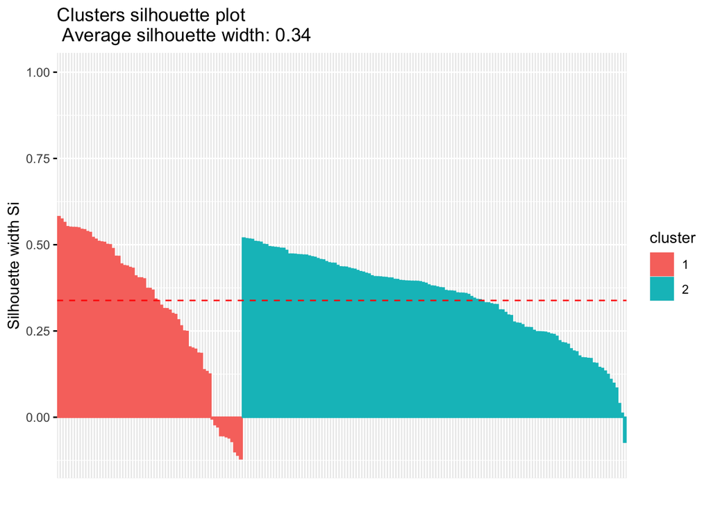

```r
fviz_silhouette(res.pam)
```

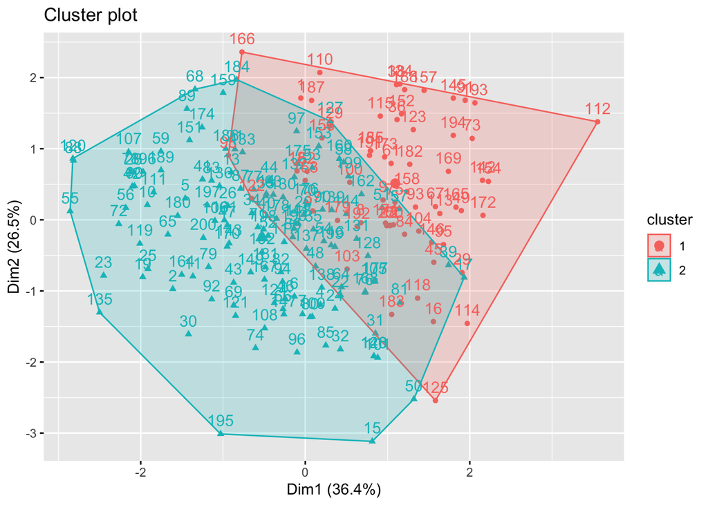

```r
fviz_cluster(list(data = lima_muestreo[,c(2:5)], cluster = lima_muestreo$pam))
```

```
##   cluster size ave.sil.width
## 1       1   41          0.55
## 2       2  159          0.34
```

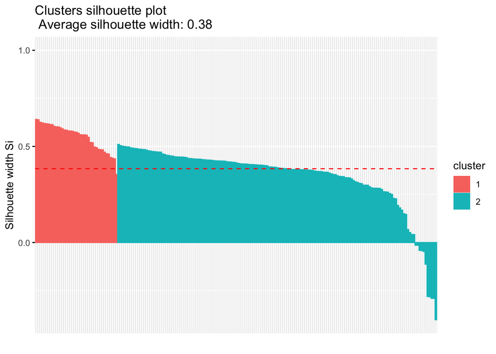

```r
fviz_silhouette(res.agnes)
```

```
##   cluster size ave.sil.width
## 1       1   55          0.42
## 2       2  145          0.37
```

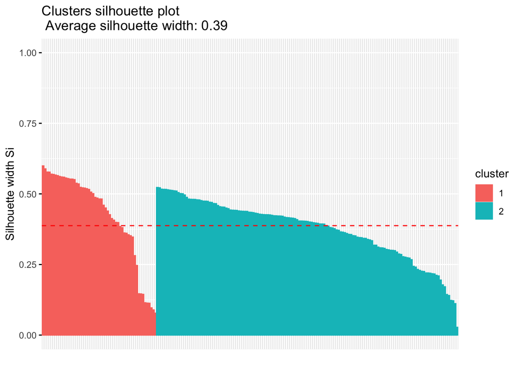

```r
fviz_silhouette(res.diana)
```

```r
dend1=pltree(res.agnes,cex = 0.5,hang = -1,main = "Agnes")
```

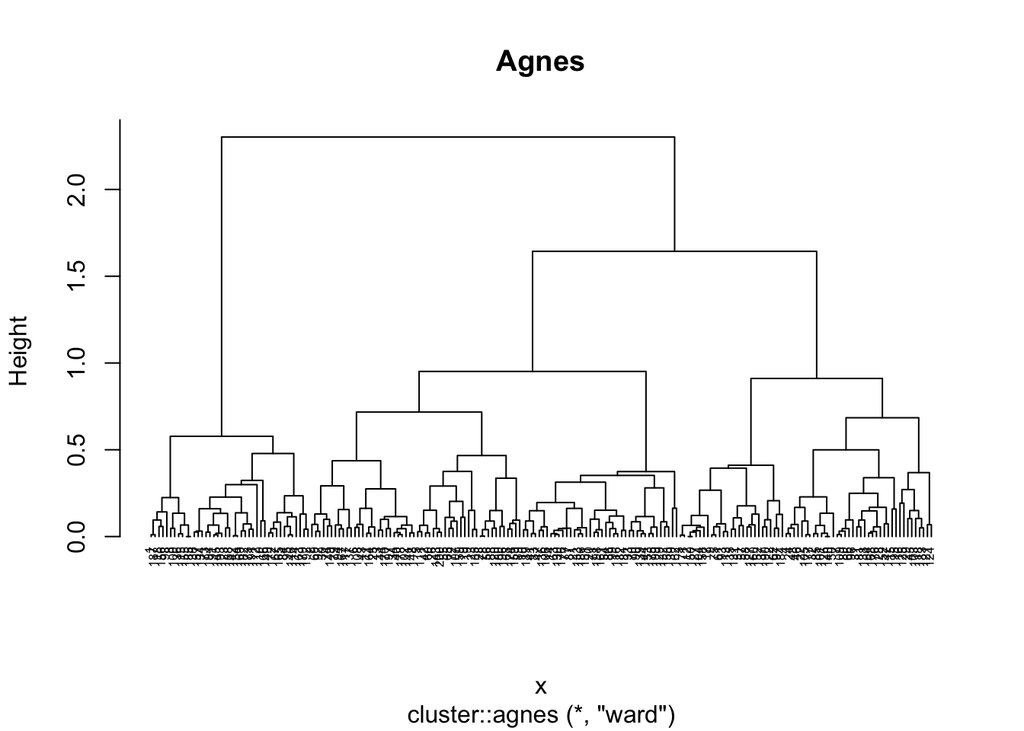

```r
dend2=pltree(res.diana,cex = 0.5,hang = -1,main = "Diana")
```

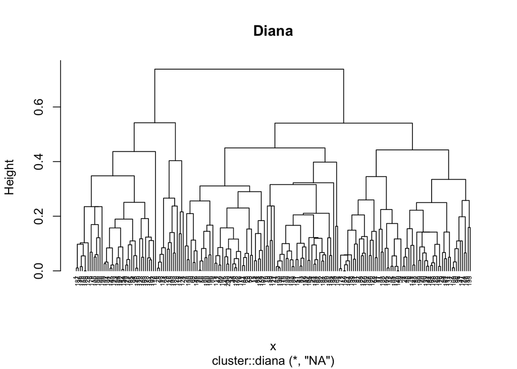

```r
library(dendextend)
```

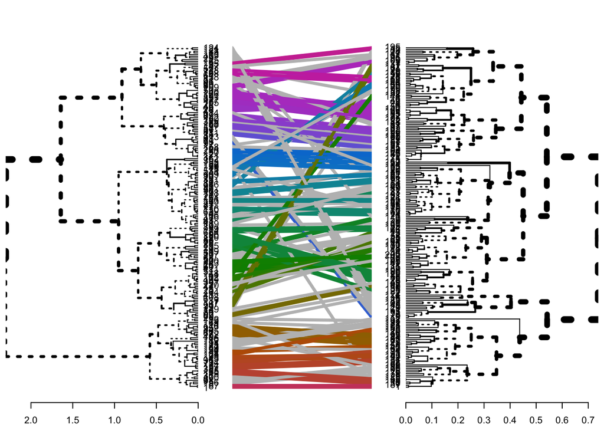

```r
dendAG <- as.dendrogram (res.agnes)
dendDI<- as.dendrogram (res.diana)
tanglegram(dendAG, dendDI)
```

```r
modelo1=lm(lima2$Edad~lima2$`Desconfianza en uso de TIC`+lima2$`Capacitación en uso de TIC`+factor(lima2$`Uso de tecnologia en enseñanza`))
```

```r
library(stargazer)
stargazer(modelo1,type = "text",intercept.bottom = FALSE)
```

```
##
## ===============================================================
##                                         Dependent variable:
##                                     ---------------------------
##                                                Edad
## ---------------------------------------------------------------
## Constant                                     47.916***
##                                               (1.535)
##
## `Desconfianza en uso de TIC`                  0.420**
##                                               (0.208)
##
## `Capacitación en uso de TIC`                 -1.878***
##                                               (0.214)
##
## `Uso de tecnologia en enseñanza`)Si          -2.211***
##                                               (0.722)
##
## ---------------------------------------------------------------
## Observations                                    767
## R2                                             0.106
## Adjusted R2                                    0.102
## Residual Std. Error                      9.970 (df = 763)
## F Statistic                           30.046*** (df = 3; 763)
## ===============================================================
## Note:                               *p<0.1; **p<0.05; ***p<0.01
```

Como podemos observar las variables seleccionadas afectan significativamente a la edad, la desconfianza en uso de las TIC en la enseñanza hace que aumente la edad del docente; mientras que el nivel de capacitación en el uso de TIC y que se considere importante el uso de las tecnologías e internete en la enseñanza hace que la edad del docente sea menor. Es decir que un docente más joven comprende la importancia de las TIC en la enseñaza y por ende se ha capacitado en el uso de las mismas para poder enseñar.

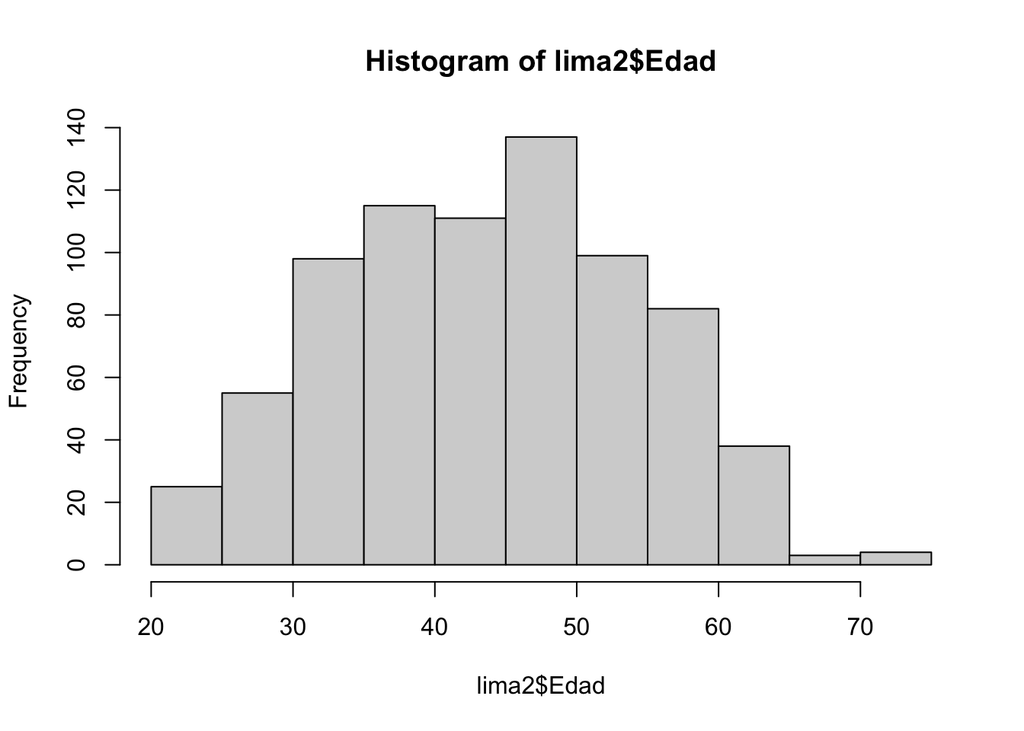

```r
hist(lima2$Edad)
```

Si observamos la distribuciones de edad de los docentes en el siguiente histograma podemos observar que en el departamento de Lima la mayoría de profesores se encuentran entre los 35 y 55 años, esto sumado a que justo esta parte de la población del cuerpo de docentes es la que está menos familiarizada con el uso de las TIC en enseñanza esto nos puede explicar porque fue muy difícil la adopción de un método virtual de enseñanza. La población de profesores más aptos para asumir un rol eficiente en los nuevos métodos de enseñanza a raíz de la pandemia del Covid-19 eran los docentes más jovenes, sin embargo este grupo es reducido en la población de docentes.

```r
modelo2=lm(lima2$Ingresos~lima2$Edad)
stargazer(modelo2,type = "text",intercept.bottom = FALSE)
```

```
##
## ===============================================
##                         Dependent variable:
##                     ---------------------------
##                              Ingresos
## -----------------------------------------------
## Constant                    857.889***
##                              (128.048)
##
## Edad                         18.837***
##                               (2.809)
##
## -----------------------------------------------
## Observations                    767
## R2                             0.056
## Adjusted R2                    0.054
## Residual Std. Error     818.057 (df = 765)
## F Statistic           44.969*** (df = 1; 765)
## ===============================================
## Note:               *p<0.1; **p<0.05; ***p<0.01
```

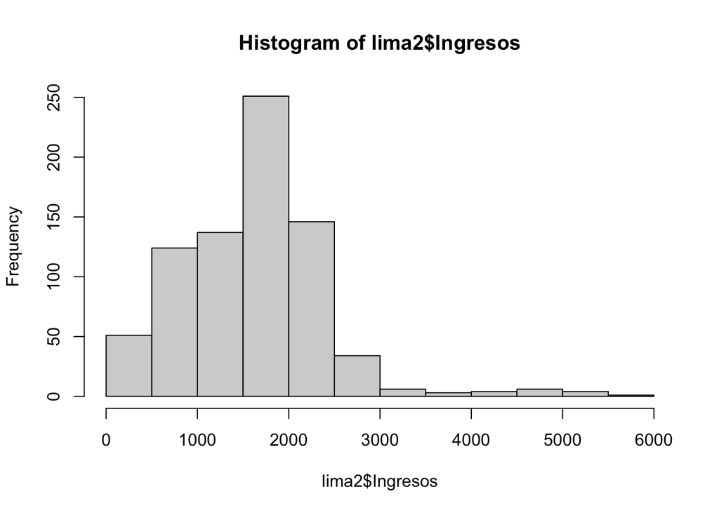

```r
hist(lima2$Ingresos)
```

Como podemos observar, la edad tiene una relación directa y significativa con los ingresos. Así también podemos observar que los ingresos se concentran entre los 1500 y los 2000 soles, si bien hay ingresos que superan los 3000 soles son mínimos los casos, esto desincentiva a jóvenes a elegir la pedagogía como carrera a seguir, y son justamente los jóvenes aquellos que estarían más aptos para afrontar los nuevos retos en un mundo de globalización y uso de las TIC en la enseñanza. #Conclusiones En base a a la data trabajada podemos afirmar que existe una relación entre la adopción y uso de las TIC en la enseñanza y la edad, docentes más jóvenes son más propensos a capacitarse y considerar importante el uso de las nuevas tecnologías en la educación ya que esto facilita el aprendizaje colaborativo de los estudiantes y amplia las oportunidades de acceso a la información. Al ser más jóvenes los docentes, están más familiarizados con el uso de nuevos programas, equipamentos y métodos que aprovechen la tecnología en su enseñanza. De esta manera, si previo a la pandemia los docentes hubieran sido en su mayoría jóvenes, la transición a las clases virtuales para el sector primario y secundario se hubiera dado de manera más orgánica y satisfactoria.

#ANEXO 1

```r
library(cluster)

set.seed(123)
g.dist = daisy(lima_muestreo[,c(2:5)], metric="gower")
```

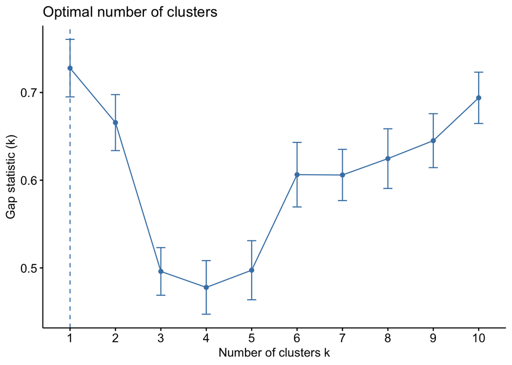

```r
## para PAM
library(ggplot2)
library(factoextra)
fviz_nbclust(lima_muestreo[,c(2:5)], pam,diss=g.dist,method = "gap_stat",k.max = 10,verbose = F)
```

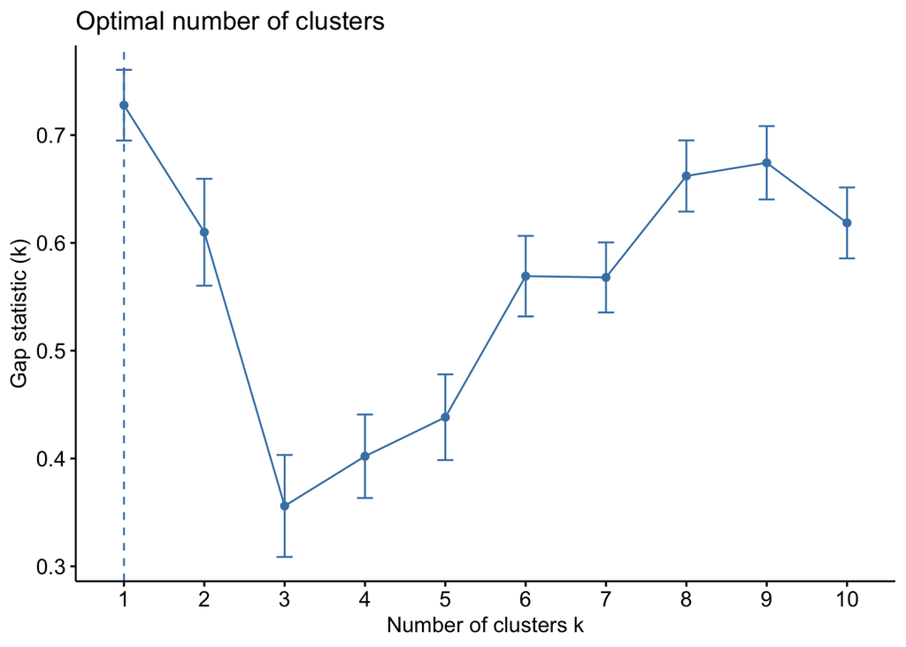

```r
## PARA JERARQUICO

fviz_nbclust(lima_muestreo[,c(2:5)], hcut,diss=g.dist,method = "gap_stat",k.max = 10,verbose = F,hc_func = "agnes")
```

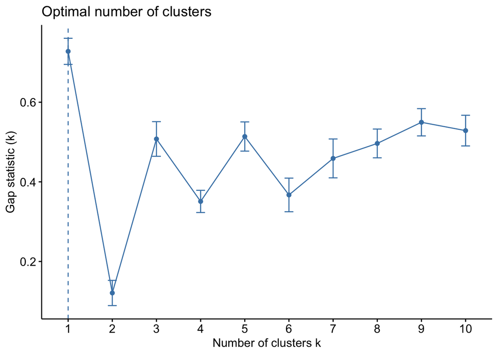

```r
## PARA JERARQUICO

fviz_nbclust(lima_muestreo[,c(2:5)], hcut,diss=g.dist,method = "gap_stat",k.max = 10,verbose = F,hc_func = "diana")
```

#ANEXO 2: Exploración de latentes

```r
dontselect=c("Departamento")
select=setdiff(names(lima3),dontselect)
theData=lima3[,select]

library(polycor)
corMatrix=polycor::hetcor(theData)$correlations
```

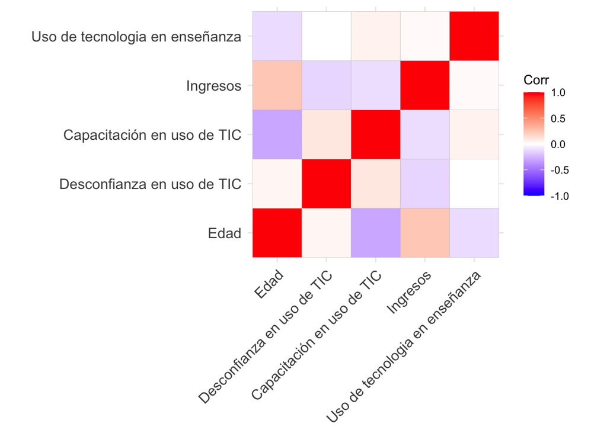

```r
library(ggcorrplot)

ggcorrplot(corMatrix)
```

```r
library(psych)
psych::KMO(corMatrix)
```

```
## Kaiser-Meyer-Olkin factor adequacy
## Call: psych::KMO(r = corMatrix)
## Overall MSA =  0.51
## MSA for each item =
##                           Edad     Desconfianza en uso de TIC
##                           0.50                           0.40
##     Capacitación en uso de TIC                       Ingresos
##                           0.55                           0.53
## Uso de tecnologia en enseñanza
##                           0.50
```

```r
cortest.bartlett(corMatrix,n=nrow(theData))$p.value>0.05
```

```
## [1] FALSE
```

```r
library(matrixcalc)

is.singular.matrix(corMatrix)
```

```
## [1] FALSE
```

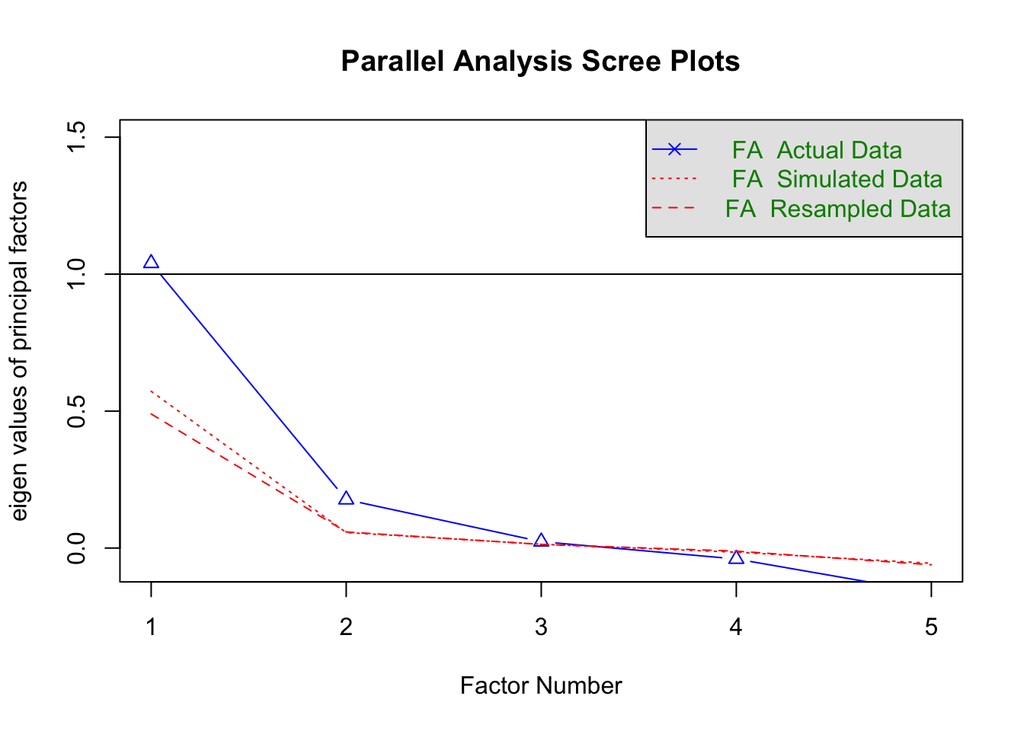

```
## Parallel analysis suggests that the number of factors =  2  and the number of components =  NA
```

```r
fa.parallel(theData,fm = 'ML', fa = 'fa',correct = T)
```

```r
library(GPArotation)
resfa <- fa(theData,
            nfactors = 2,
            cor = 'mixed',
            rotate = "varimax",
            fm="minres")
```

```r
print(resfa$loadings)
```

```
##
## Loadings:
##                                MR1    MR2
## Edad                            0.999
## Desconfianza en uso de TIC             0.609
## Capacitación en uso de TIC     -0.325  0.191
## Ingresos                        0.243 -0.247
## Uso de tecnologia en enseñanza -0.145
##
##                  MR1   MR2
## SS loadings    1.184 0.469
## Proportion Var 0.237 0.094
## Cumulative Var 0.237 0.331
```

```r
print(resfa$loadings,cutoff = 0.5)
```

```
##
## Loadings:
##                                MR1    MR2
## Edad                            0.999
## Desconfianza en uso de TIC             0.609
## Capacitación en uso de TIC
## Ingresos
## Uso de tecnologia en enseñanza
##
##                  MR1   MR2
## SS loadings    1.184 0.469
## Proportion Var 0.237 0.094
## Cumulative Var 0.237 0.331
```

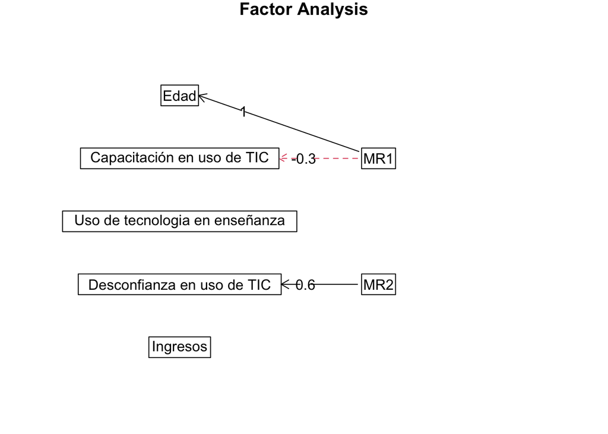

```r
fa.diagram(resfa)
```

```r
sort(resfa$communality)
```

```
## Uso de tecnologia en enseñanza                       Ingresos
##                     0.02092868                     0.12017241
##     Capacitación en uso de TIC     Desconfianza en uso de TIC
##                     0.14195457                     0.37211038
##                           Edad
##                     0.99770557
```

```r
sort(resfa$complexity)
```

```
## Uso de tecnologia en enseñanza                           Edad
##                       1.000986                       1.001051
##     Desconfianza en uso de TIC     Capacitación en uso de TIC
##                       1.006262                       1.618270
##                       Ingresos
##                       1.999403
```

```r
as.data.frame(resfa$scores)%>%head()
```

```
##          MR1        MR2
## 1 -1.1491381  0.2657623
## 2 -1.2563695 -0.1753601
## 3  0.4344500  0.3380223
## 4         NA         NA
## 5 -0.8793384 -0.5523696
## 6 -0.4709789  0.4116044
```

#LINK AL REPOSITORIO con el código RMD y la metadata: https://github.com/alvarojt/Estadistica2